# ExpHunterSuite: Clusters Functional Report

SysBioLab

# **Functional Report**

## **MF - Over Representation Analysis**

The ORA method takes a group of significant genes and performs a Fisher’s exact test for each term of the selected functional category.

**Barplot**

The most highly signficant categories in ascending order, according to adjusted p-value. The x-axis represents the number of significant genes found within the functional category.

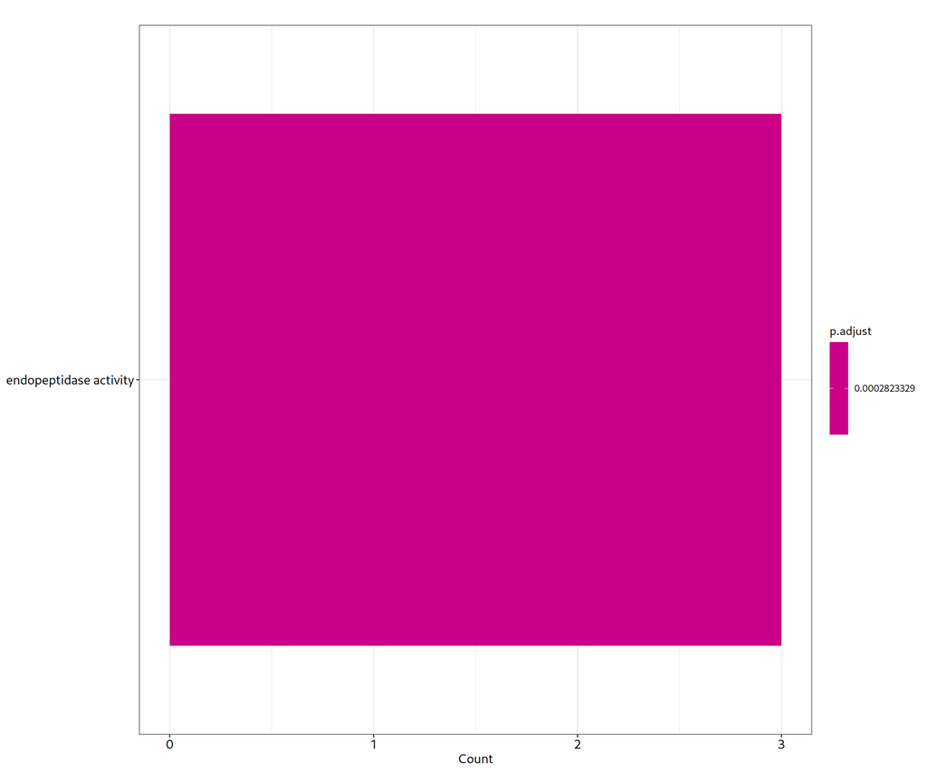

**Dotplot**

The most highly signficant categories in descending in categories of gene ratio, defined as the proportion of significant genes that are found in the functional category. The x-axis represents the gene ratio and the dot size the number of genes associated with the functional category.

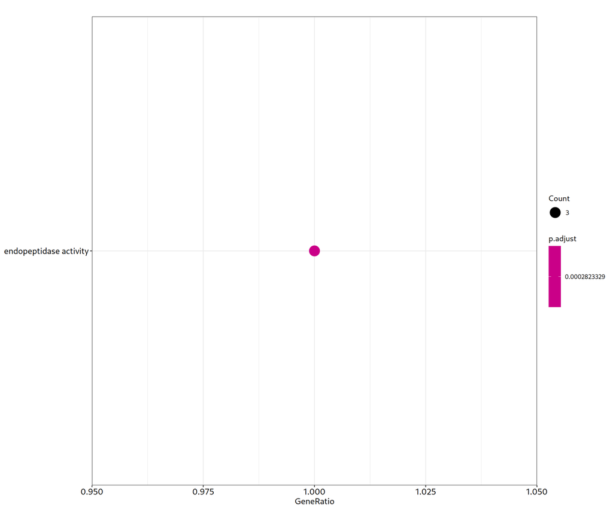

**Gene-Concept Network**

The network connects the top functional categories (brown nodes) to their associated genes (grey or colored nodes). The size of the functional category nodes shows the number of connected genes.

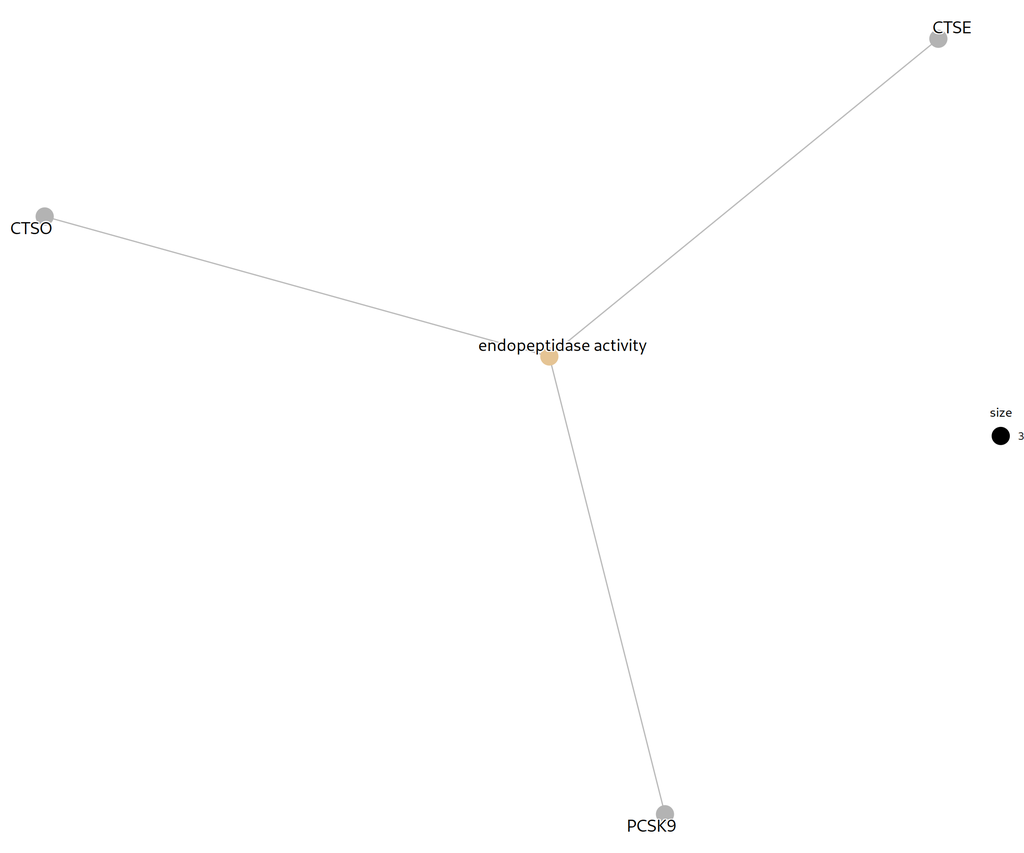

**Enrich Map plot**

The top functional categories (nodes), connected if they share genes. Edge thickness represents the number of shared genes. Nodes size represents the number of significant genes within the category.

This graph can not be plotted because fewer than two functional categories were enriched

**Heatplot**

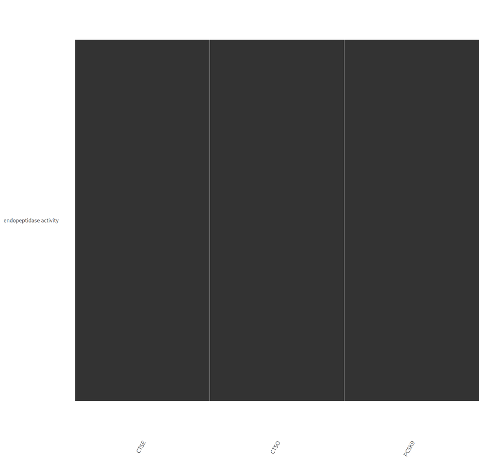

**Upsetplot**

Genes are clustered according to shared enriched categories. The y-axis shows the number of genes belonging to the different clusters (top) and categories to which they belong (bottom).

[output not shown]

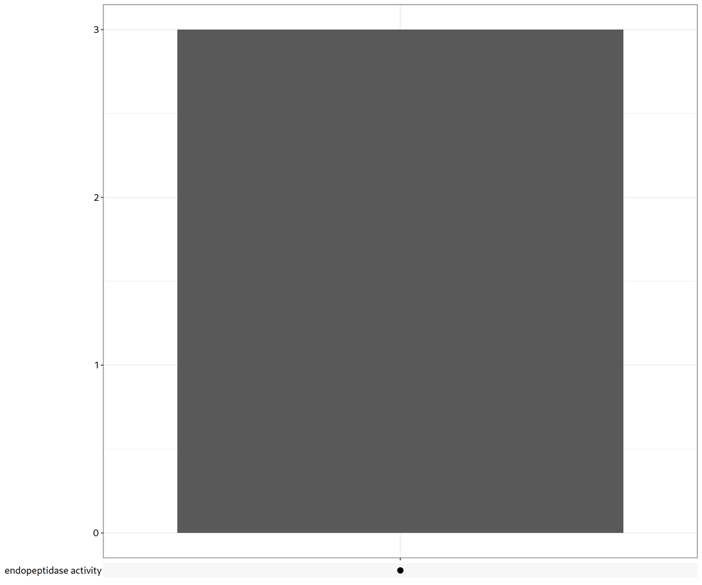

## **BP - Over Representation Analysis**

The ORA method takes a group of significant genes and performs a Fisher’s exact test for each term of the selected functional category.

**Barplot**

The most highly signficant categories in ascending order, according to adjusted p-value. The x-axis represents the number of significant genes found within the functional category.

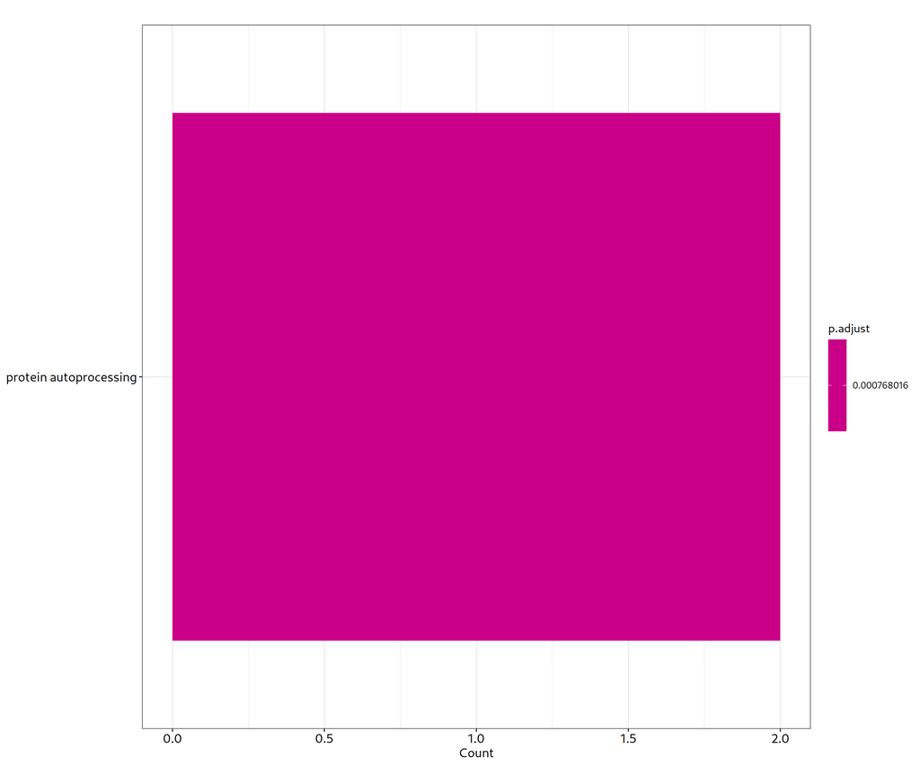

**Dotplot**

The most highly signficant categories in descending in categories of gene ratio, defined as the proportion of significant genes that are found in the functional category. The x-axis represents the gene ratio and the dot size the number of genes associated with the functional category.

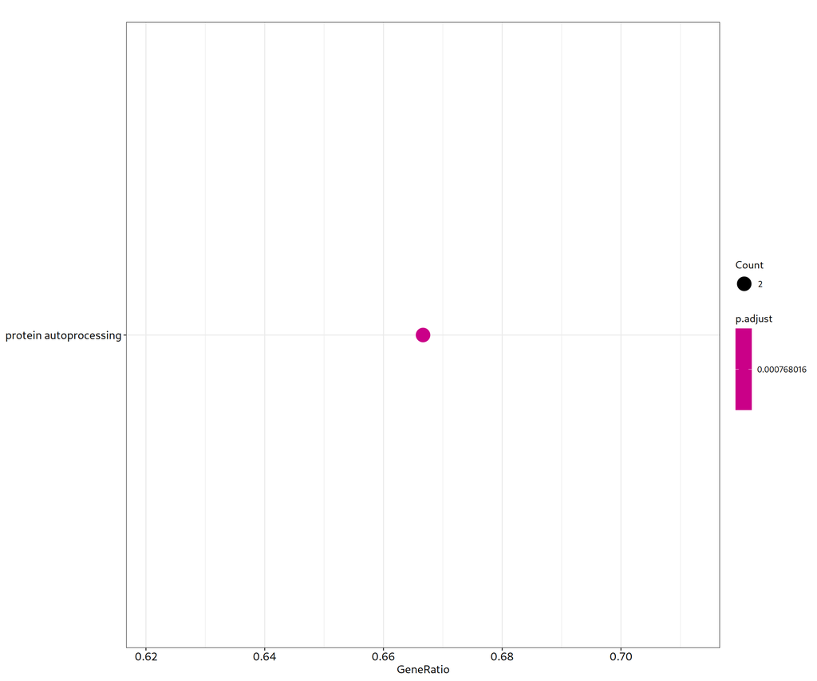

**Gene-Concept Network**

The network connects the top functional categories (brown nodes) to their associated genes (grey or colored nodes). The size of the functional category nodes shows the number of connected genes.

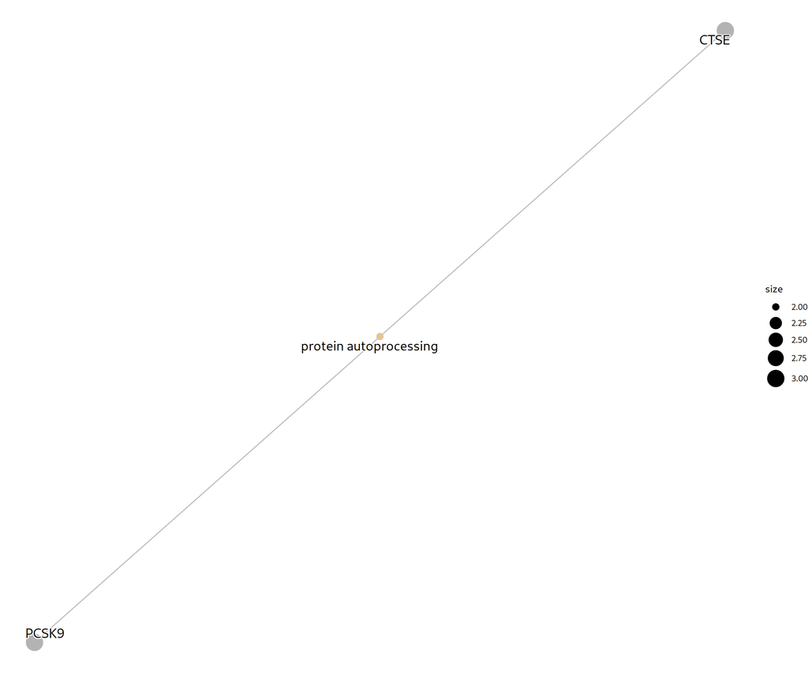

**Enrich Map plot**

The top functional categories (nodes), connected if they share genes. Edge thickness represents the number of shared genes. Nodes size represents the number of significant genes within the category.

This graph can not be plotted because fewer than two functional categories were enriched

**Heatplot**

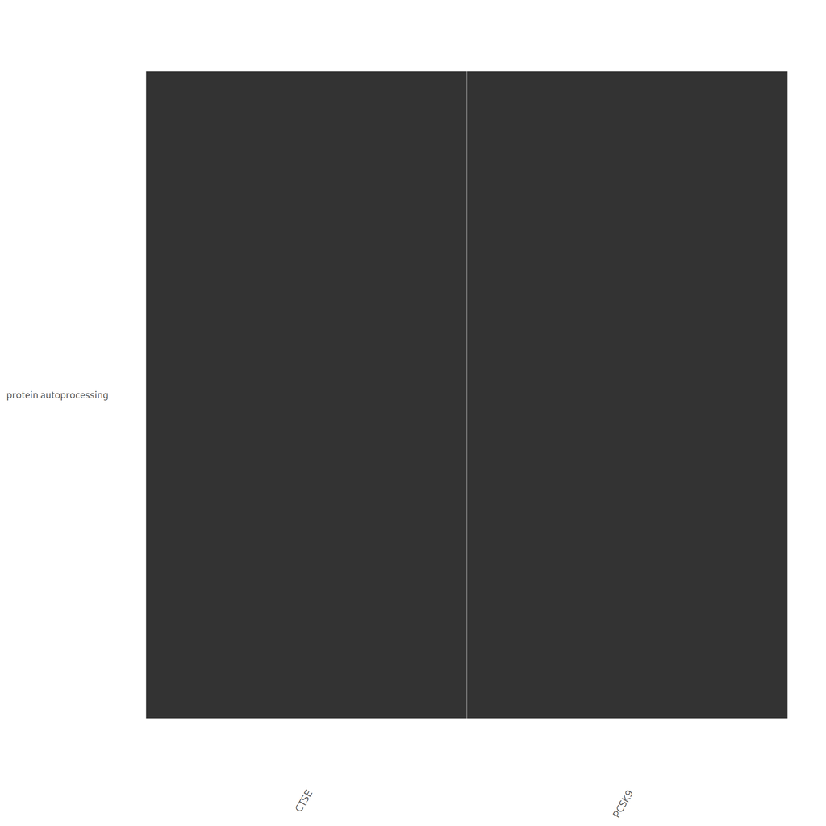

**Upsetplot**

Genes are clustered according to shared enriched categories. The y-axis shows the number of genes belonging to the different clusters (top) and categories to which they belong (bottom).

[output not shown]

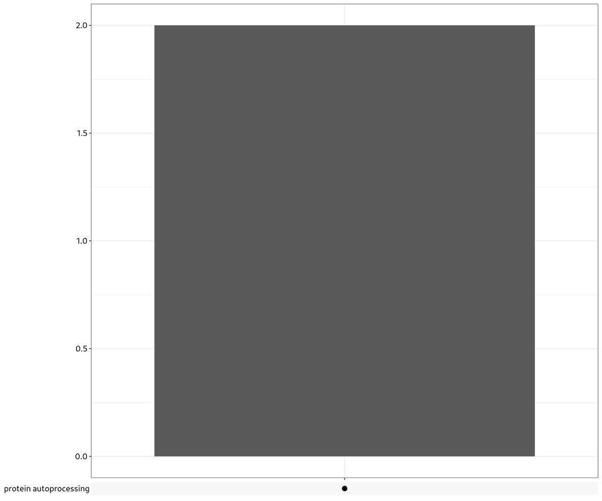

## **CC - Over Representation Analysis**

No enrichment found for CC

## **KEGG - Over Representation Analysis**

The ORA method takes a group of significant genes and performs a Fisher’s exact test for each term of the selected functional category.

**Barplot**

The most highly signficant categories in ascending order, according to adjusted p-value. The x-axis represents the number of significant genes found within the functional category.

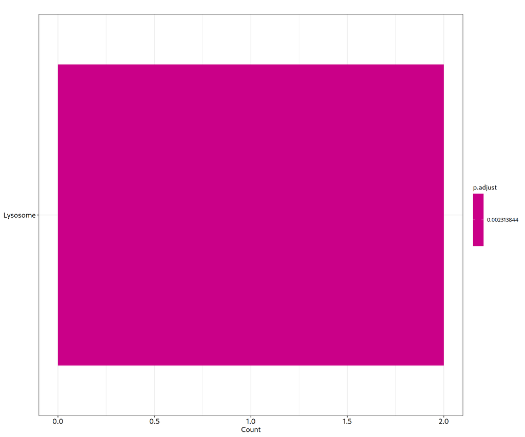

**Dotplot**

The most highly signficant categories in descending in categories of gene ratio, defined as the proportion of significant genes that are found in the functional category. The x-axis represents the gene ratio and the dot size the number of genes associated with the functional category.

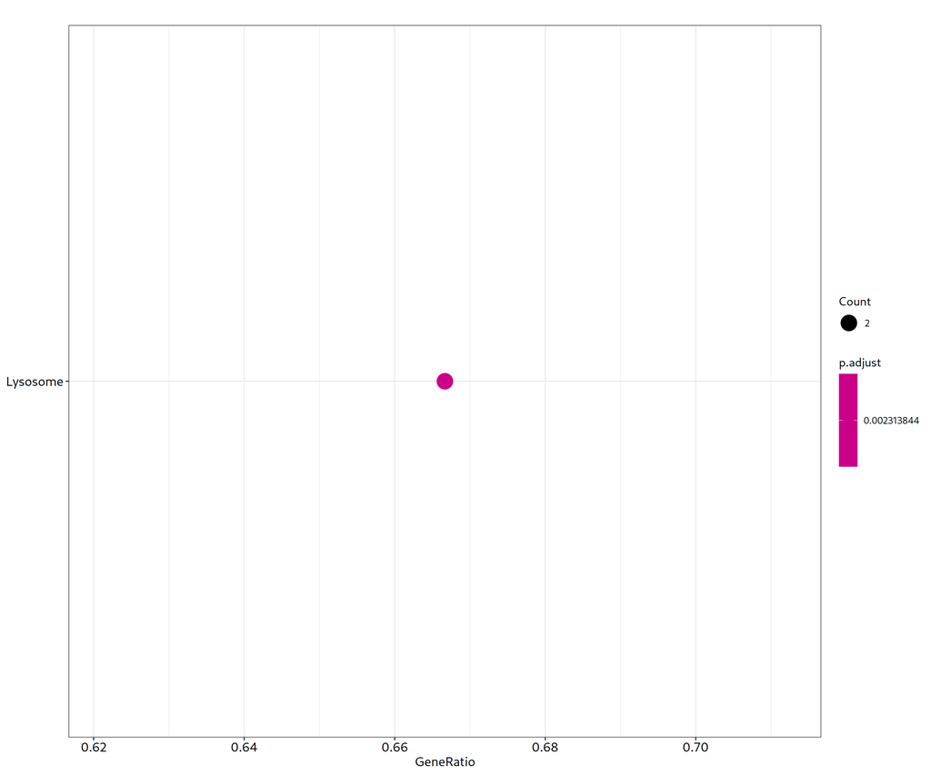

**Gene-Concept Network**

The network connects the top functional categories (brown nodes) to their associated genes (grey or colored nodes). The size of the functional category nodes shows the number of connected genes.

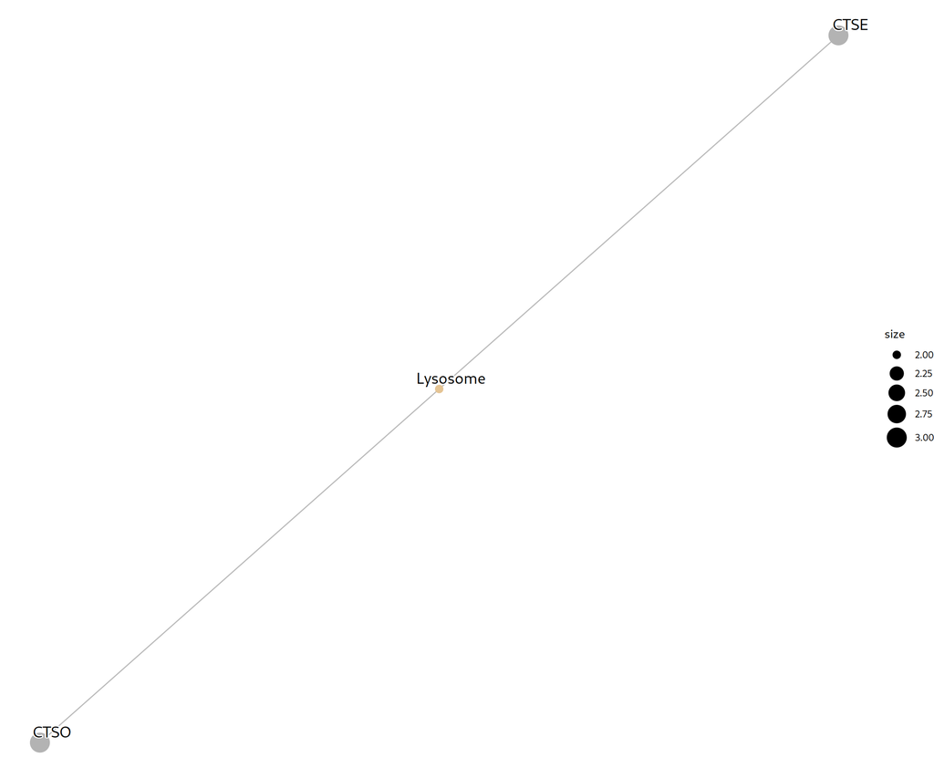

**Enrich Map plot**

The top functional categories (nodes), connected if they share genes. Edge thickness represents the number of shared genes. Nodes size represents the number of significant genes within the category.

This graph can not be plotted because fewer than two functional categories were enriched

**Heatplot**

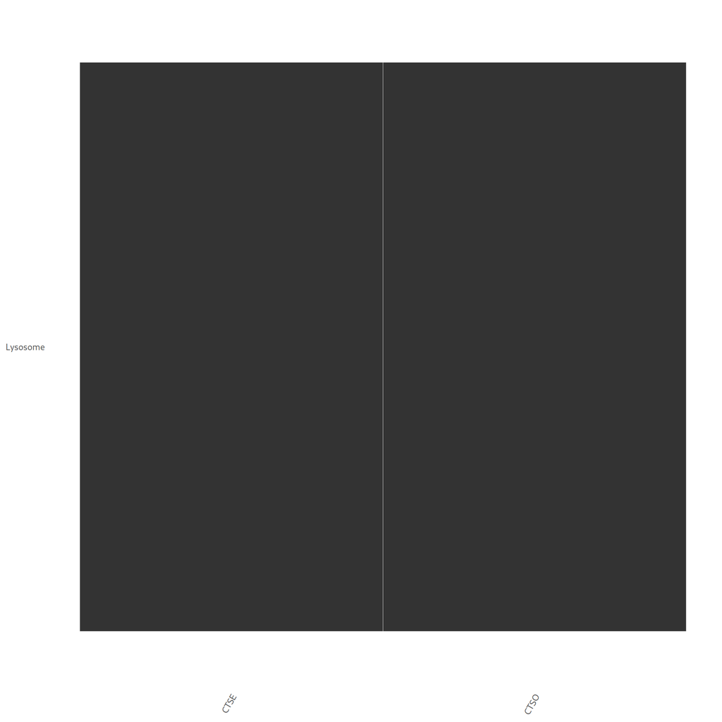

**Upsetplot**

Genes are clustered according to shared enriched categories. The y-axis shows the number of genes belonging to the different clusters (top) and categories to which they belong (bottom).

[output not shown]

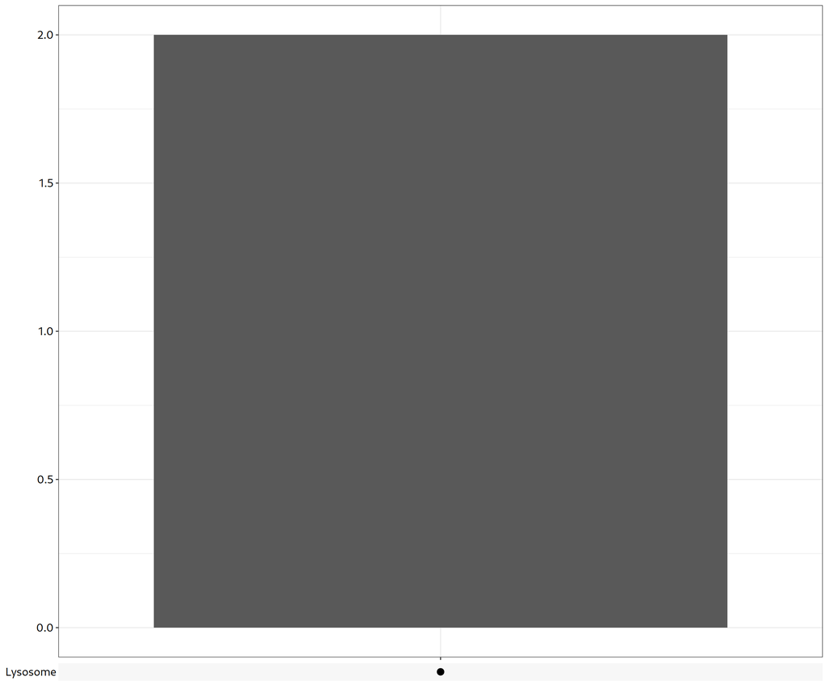

## **Reactome - Over Representation Analysis**

The ORA method takes a group of significant genes and performs a Fisher’s exact test for each term of the selected functional category.

**Barplot**

The most highly signficant categories in ascending order, according to adjusted p-value. The x-axis represents the number of significant genes found within the functional category.

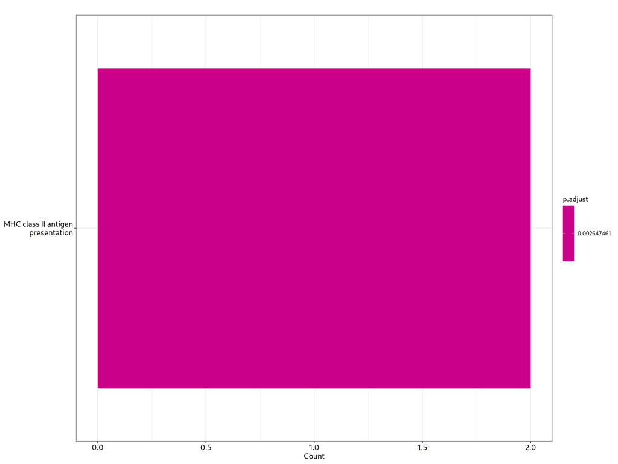

**Dotplot**

The most highly signficant categories in descending in categories of gene ratio, defined as the proportion of significant genes that are found in the functional category. The x-axis represents the gene ratio and the dot size the number of genes associated with the functional category.

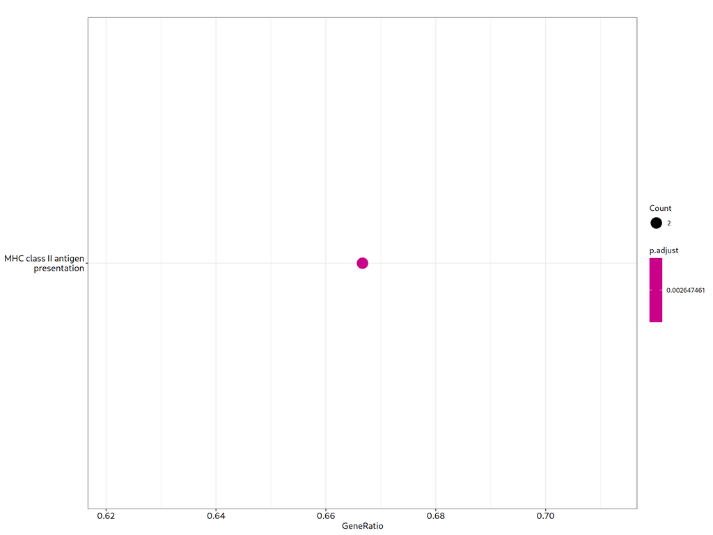

**Gene-Concept Network**

The network connects the top functional categories (brown nodes) to their associated genes (grey or colored nodes). The size of the functional category nodes shows the number of connected genes.

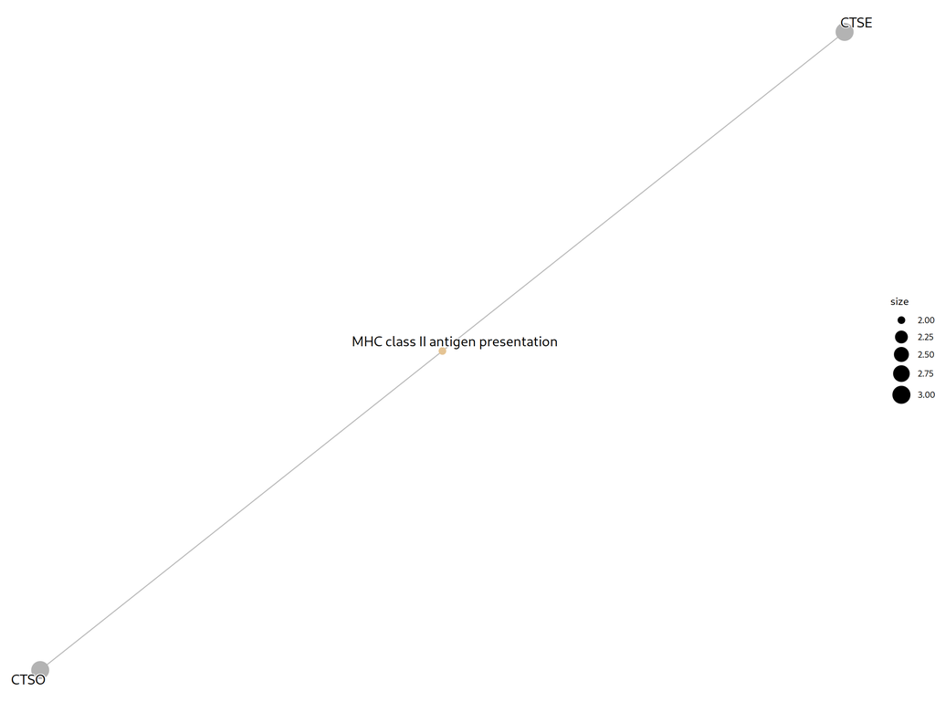

**Enrich Map plot**

The top functional categories (nodes), connected if they share genes. Edge thickness represents the number of shared genes. Nodes size represents the number of significant genes within the category.

This graph can not be plotted because fewer than two functional categories were enriched

**Heatplot**

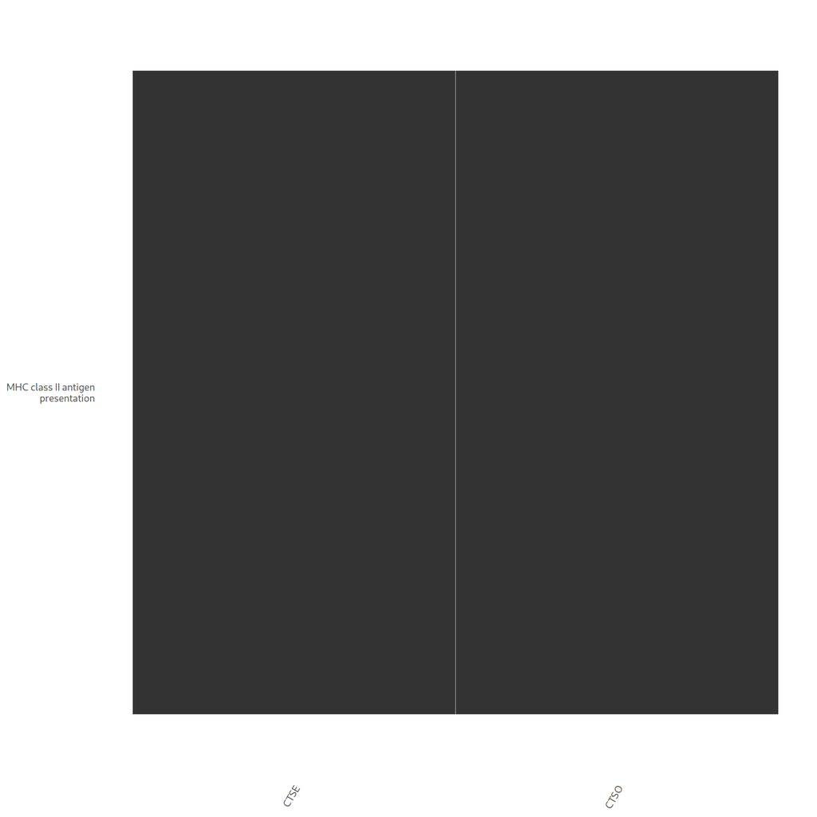

**Upsetplot**

Genes are clustered according to shared enriched categories. The y-axis shows the number of genes belonging to the different clusters (top) and categories to which they belong (bottom).

[output not shown]

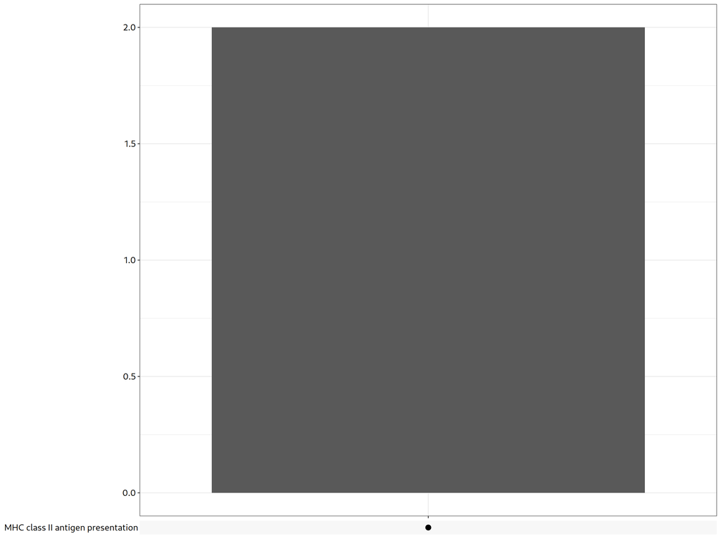

## **DO - Over Representation Analysis**

No enrichment found for DO

## **DGN - Over Representation Analysis**

No enrichment found for DGN